# Structural Equation Modeling Based Meta-Analysis - multivarate

## Multivariate context

- When the research questions become more complicated, a single effect-size may not be sufficient to summarize the effect in the pry studies. Multiple effect sizes are required to quantify the effects of the study.
- An extension of the univariate approach.
- The data for the analysis is in a vector or matrix form.
- Key points to consider: (sources of dependency)
  - Within-study variance: This is the variation due to sampling in the individual studies, typically represented by a covariance matrix.
  - Between-study variance: Represented by $(\tau^2)$, this accounts for the variability in true effect sizes across studies.
  - given one study, it is difficult to estimate this dependence.

### Stages of MASEM

- Two stages (TSSEM) of MASEM
  - pool the correlation matrix together
  - pooled correlation matrix is used to fit the SEM
- The metaSEM package handles both fixed- or random-effects models automatically.
- TSSEM uses Maximum Likelihood (ML) to obtain the pooled correlation matrix and test for heterogeneity, making it effective for both fixed- and random-effects models.
- The parameter estimates are unbiased ensuring the results are reliable and valid.
- Effective in handling missing data when correlation estimates are MCAR or MAR.

### Stage 1

#### Fixed-effects model

- Assumes common population (covariance) correlation matrices for all studies
- If an ith study has a covariance matrix, the matrix can be decomposed into a product of the matrices of correlations and standard deviations.
  $$\boldsymbol{\sum_i}(\theta) = \boldsymbol{D_i} \boldsymbol{P_i} \boldsymbol{D_i}$$
  $\boldsymbol{\sum}(\theta_i)$ = model implied covariance matrix, $\boldsymbol{D_i}$ = diagonal matrix of standard deviations, $\boldsymbol{P_i}$ = correlation matrix in the i_th study.
- A constraint is imposed such that $\boldsymbol{\rho} = \boldsymbol{P_1}=\boldsymbol{P_2}=\boldsymbol{P_3}...=\boldsymbol{P_k}$
- $\boldsymbol{D_i}$ may vary across studies, however if you assume common covariance (homogeneity of variance) , we can just constrain the matrices.
  $$\boldsymbol{D} = \boldsymbol{D_1}=\boldsymbol{D_2}=\boldsymbol{D_3}...=\boldsymbol{D_k}$$
- A likelihood ratio test (LR) can be used to test the null hypothesis homogeneity of correlation matrices.
- Various goodness-of-fit may also be used to evaluate the homogeneity of correlation matrices.

#### Random-effects model

- The assumption of homogeneity of correlation matrices may not be reasonable.
- The pry studies are independently conducted by different researchers, so
  - samples
  - measures
  - researches focuses are likely different.
- more appropriate method to analyze the data.
- Using this Random-effects model, we treat the correlation matrices as vectors of multivariate effect-sizes (multiple variables). Let $\boldsymbol{r_i} = vechs(\boldsymbol{R_i})$ be the $p(p-1)/2$ X 1 vector of a sample correlation for p variables.
  - e.g., if p = 3 (variables), then the number of unique element in the correlation matrix $(\boldsymbol{R_i})$ will be 3(3-1)/2 = 3.
- If dealing with a covariance matrix, the number of unique elements will be $p(p+1)/2$ = $\boldsymbol{s_i} = vech(\boldsymbol{S_i})$
- The model for the sample correlation vector = $\boldsymbol{r_i} = {P_R} + \boldsymbol{u_i} + \boldsymbol{e_i}$.
- ${\rho_R}$ = $p(p-1)/2$ X 1 = average true correlation vector, $Var(\boldsymbol{U_i})$ = between study variance component called Tau-squared, $(\boldsymbol{\tau^2})$ $Var(\boldsymbol{e_i})$ = sampling covaraiance matrix.

$\boldsymbol{u_i} \sim N(0, \boldsymbol{\tau^2})$

$\boldsymbol{e_i} \sim N(0, \boldsymbol{V_i})$

$\boldsymbol{\tau^2}$ can be `non-positive` definite if we have many variables(effect-sizes), and not enough data. Thus, the results cannot be trusted.

The solution is to fix $\boldsymbol{\tau^2}$ to a diagonal matrix instead of a symmetric matrix. (specify the argument`RE.type="Diag"`in the TSSEM function)

### Stage 2

- In the stage 1 analysis a vector of pooled correlations $\boldsymbol{r}$ and its asymptotic covariance matrix $\boldsymbol{V}$ are obtained.
- Note that $\boldsymbol{\tau^2}$ is not directly involved in fitting the correlation structure in this stage. yet we still have to take it into account to determine the heterogeneity of the random effects.
- It is incorrect to:
  - use a pooled correlation matrix as if it were an observed correlation matrix to fit SEM (Cheung and Chan 2005b)
  - analyze the pooled correlation matrix, and to use it as if it were a covariance matrix.
    - specifically, the chi-square statistics and(or) the SEs of the parameter estimates may be incorrect.
- The issue above is addressed in the TSSEM approach which uses the WLS estimation to fit the propsed model in this stage.
- This is done by minimizing the fit function $F_{\text{wls}} = (\boldsymbol{r} - \boldsymbol{r}_{\text{model}})^T \boldsymbol{V}^{-1} (\boldsymbol{r} - \boldsymbol{r}_{\text{model}})$ = vector containing the lower triangular element of the sample correlation matrix $\boldsymbol{r}_{\text{model}}$ = vector containing the lower triangular element of the implied covariance matrix $\boldsymbol{V}^{-1}$ = the asymptotic covariance matrix from the first stage.
- LR statistics is used to test the appropriateness of the structural model, and SE is used to test the significance of the parameter estimates.

## R illustration

### Digman data set

- The digman (1997) dataset reported a second-order factor analysis on a five-factor model with 14 studies.
- Two factors are
  - Alpha ~ agreeableness (A), conscientiousness (C), and emotional stability (ES)
  - Beta ~ extroversion (E), and intellect (I).
- We use the TSSEM approach to test the proposed model.
- Correlation matrices (data) are stored in `Digman97$data`
- sample sizes are stored in `Digman97$n`

```r
library(metaSEM) # load package
head(Digman97$data) # first six rows of the data (correlation matrices from 6 studies)
```

```
$`Digman 1 (1994)`
       A     C   ES     E    I
A   1.00  0.62 0.41 -0.48 0.00
C   0.62  1.00 0.59 -0.10 0.35
ES  0.41  0.59 1.00  0.27 0.41
E  -0.48 -0.10 0.27  1.00 0.37
I   0.00  0.35 0.41  0.37 1.00

$`Digman 2 (1994)`
       A    C   ES     E     I
A   1.00 0.39 0.53 -0.30 -0.05
C   0.39 1.00 0.59  0.07  0.44
ES  0.53 0.59 1.00  0.09  0.22
E  -0.30 0.07 0.09  1.00  0.45
I  -0.05 0.44 0.22  0.45  1.00

$`Digman 3 (1963c)`
      A     C   ES     E    I
A  1.00  0.65 0.35  0.25 0.14
C  0.65  1.00 0.37 -0.10 0.33
ES 0.35  0.37 1.00  0.24 0.41
E  0.25 -0.10 0.24  1.00 0.41
I  0.14  0.33 0.41  0.41 1.00

$`Digman & Takemoto-Chock (1981b)`
       A     C   ES     E     I
A   1.00  0.65 0.70 -0.26 -0.03
C   0.65  1.00 0.71 -0.16  0.24
ES  0.70  0.71 1.00  0.01  0.11
E  -0.26 -0.16 0.01  1.00  0.66
I  -0.03  0.24 0.11  0.66  1.00

$`Graziano & Ward (1992)`
      A    C   ES    E    I
A  1.00 0.64 0.35 0.29 0.22
C  0.64 1.00 0.27 0.16 0.22
ES 0.35 0.27 1.00 0.32 0.36
E  0.29 0.16 0.32 1.00 0.53
I  0.22 0.22 0.36 0.53 1.00

$`Yik & Bond (1993)`
      A    C   ES    E    I
A  1.00 0.66 0.57 0.35 0.38
C  0.66 1.00 0.45 0.20 0.31
ES 0.57 0.45 1.00 0.49 0.31
E  0.35 0.20 0.49 1.00 0.59
I  0.38 0.31 0.31 0.59 1.00
```

```r
head(Digman97$n) # sample sizes from the above matrices.
```

```
[1] 102 149 334 162  91 656
```

#### Stage 1

- use the TSSEM1() function to pool the correlation matrices together. For the fixed-effects model in this first stage, just specify the `method="FEM"` in the argument.

```r
# Stage 1: Pooling correlation matrices using Fixed-Effects Model (FEM)
fixed1 <- tssem1(Digman97$data,
                 Digman97$n,
                 method = "FEM")  # Fixed-effects model for meta-analysis

# Display the summary of the Stage 1 analysis, including fit indices
summary(fixed1)
```

```
Call:
tssem1FEM(Cov = Cov, n = n, cor.analysis = cor.analysis, model.name = model.name,
    cluster = cluster, suppressWarnings = suppressWarnings, silent = silent,
    run = run)

Coefficients:
       Estimate Std.Error z value  Pr(>|z|)
S[1,2] 0.363278  0.013368 27.1760 < 2.2e-16 ***
S[1,3] 0.390375  0.012880 30.3076 < 2.2e-16 ***
S[1,4] 0.103572  0.015047  6.8830 5.862e-12 ***
S[1,5] 0.092286  0.015047  6.1331 8.621e-10 ***
S[2,3] 0.416070  0.012519 33.2344 < 2.2e-16 ***
S[2,4] 0.135148  0.014776  9.1464 < 2.2e-16 ***
S[2,5] 0.141431  0.014866  9.5135 < 2.2e-16 ***
S[3,4] 0.244459  0.014153 17.2724 < 2.2e-16 ***
S[3,5] 0.138339  0.014834  9.3259 < 2.2e-16 ***
S[4,5] 0.424566  0.012375 34.3070 < 2.2e-16 ***
---
Signif. codes:  0 '***' 0.001 '**' 0.01 '*' 0.05 '.' 0.1 ' ' 1

Goodness-of-fit indices:
                                     Value
Sample size                      4496.0000
Chi-square of target model       1505.4443
DF of target model                130.0000
p value of target model             0.0000
Chi-square of independence model 4471.4242
DF of independence model          140.0000
RMSEA                               0.1815
RMSEA lower 95% CI                  0.1736
RMSEA upper 95% CI                  0.1901
SRMR                                0.1621
TLI                                 0.6580
CFI                                 0.6824
AIC                              1245.4443
BIC                               412.0217
OpenMx status1: 0 ("0" or "1": The optimization is considered fine.
Other values may indicate problems.)
```

- We want to test for the homogeneity of correlation matrices in this stage 1.
  - $\chi^2(df= 130, N= 4,496) = 1505.4443, p = .0000, CFI = .6824, TLi = .6580, SRMR= .1621, RMSEA = .1815$
  - The p-value is less than .05 indicating that the correlation matrices are different from from one another, violating the homogeneity of correlation matrix assumption. This tells us that the random effects model is more suitable for the analysis.
  - The TLI and CFI values are smaller than the threshold of >.96
  - RMSEA and SRMR values are larger than the recommended threshold of <.08

```r
coef(fixed1) # extract the pooled correlation matrix
```

```
            A         C        ES         E          I
A  1.00000000 0.3632782 0.3903748 0.1035716 0.09228557
C  0.36327824 1.0000000 0.4160695 0.1351477 0.14143058
ES 0.39037483 0.4160695 1.0000000 0.2444593 0.13833895
E  0.10357155 0.1351477 0.2444593 1.0000000 0.42456626
I  0.09228557 0.1414306 0.1383390 0.4245663 1.00000000
```

#### Stage 2

- We want to fit the Structural equation model. In the Digman study the model is a factor analytic model.
- Two factors loading on 5 observed variables
- We need to specify the:
  - path from the latent factor to the observed variables (A-matrix)
  - variance-covariance structure (S-matrix)
  - selection matrix used to filter observed variables (F-matrix)
- We specify these matrices in the reticular action model (RAM)

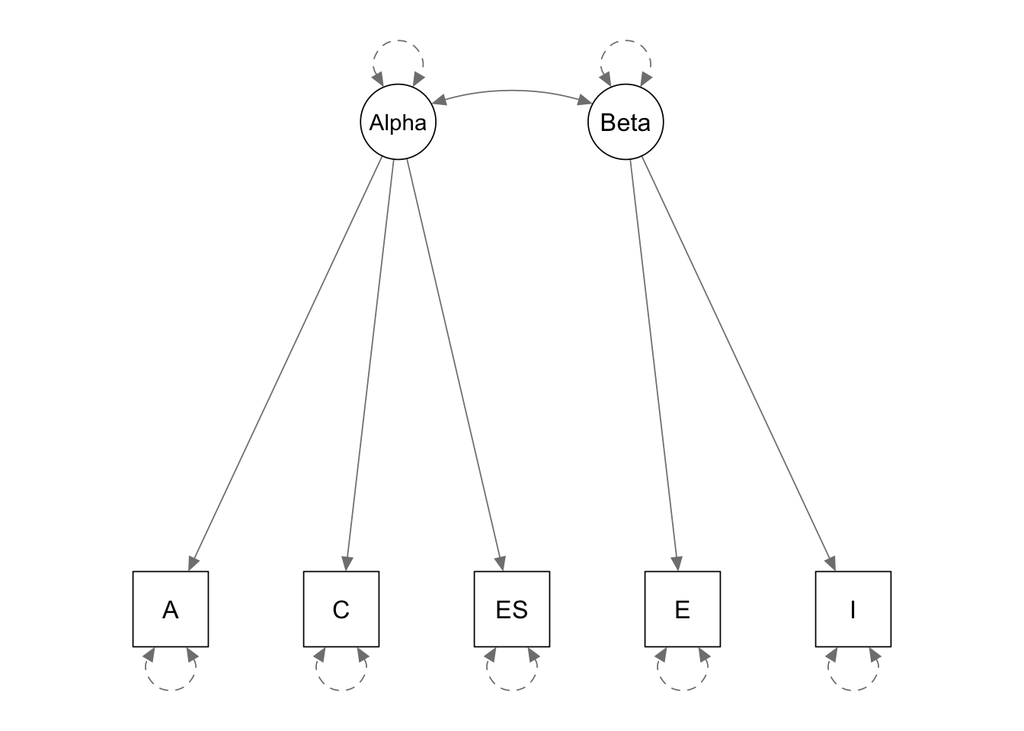

```r
model1 <- "## Factor loadings
           Alpha =~ A+C+ES
           Beta =~ E+I
           ## Factor correlation
           Alpha ~~ Beta"

plot(model1)
```

```r
RAM1 <- lavaan2RAM(model1, obs.variables=c("A","C","ES","E","I"),
                   A.notation="on", S.notation="with")
RAM1
```

```
$A
      A   C   ES  E   I   Alpha           Beta
A     "0" "0" "0" "0" "0" "0.1*AonAlpha"  "0"
C     "0" "0" "0" "0" "0" "0.1*ConAlpha"  "0"
ES    "0" "0" "0" "0" "0" "0.1*ESonAlpha" "0"
E     "0" "0" "0" "0" "0" "0"             "0.1*EonBeta"
I     "0" "0" "0" "0" "0" "0"             "0.1*IonBeta"
Alpha "0" "0" "0" "0" "0" "0"             "0"
Beta  "0" "0" "0" "0" "0" "0"             "0"

$S
      A            C            ES             E            I
A     "0.5*AwithA" "0"          "0"            "0"          "0"
C     "0"          "0.5*CwithC" "0"            "0"          "0"
ES    "0"          "0"          "0.5*ESwithES" "0"          "0"
E     "0"          "0"          "0"            "0.5*EwithE" "0"
I     "0"          "0"          "0"            "0"          "0.5*IwithI"
Alpha "0"          "0"          "0"            "0"          "0"
Beta  "0"          "0"          "0"            "0"          "0"
      Alpha             Beta
A     "0"               "0"
C     "0"               "0"
ES    "0"               "0"
E     "0"               "0"
I     "0"               "0"
Alpha "1"               "0*AlphawithBeta"
Beta  "0*AlphawithBeta" "1"

$F
   A C ES E I Alpha Beta
A  1 0  0 0 0     0    0
C  0 1  0 0 0     0    0
ES 0 0  1 0 0     0    0
E  0 0  0 1 0     0    0
I  0 0  0 0 1     0    0

$M
  A         C         ES         E         I         Alpha Beta
1 "0*Amean" "0*Cmean" "0*ESmean" "0*Emean" "0*Imean" "0"   "0"
```

```r
# Run the second stage of Two-Stage Structural Equation Modeling (TSSEM)
fixed2 <- tssem2(fixed1,
                 RAM=RAM1,
                 intervals="LB",
                 model.name = "TSSEM2 Digman97")

# Display the summary of the model
summary(fixed2)
```

```
Call:
wls(Cov = coef.tssem1FEM(tssem1.obj), aCov = vcov.tssem1FEM(tssem1.obj),
    n = sum(tssem1.obj$n), RAM = RAM, Amatrix = Amatrix, Smatrix = Smatrix,
    Fmatrix = Fmatrix, diag.constraints = diag.constraints, cor.analysis = tssem1.obj$cor.analysis,
    intervals.type = intervals.type, mx.algebras = mx.algebras,
    mxModel.Args = mxModel.Args, subset.variables = subset.variables,
    model.name = model.name, suppressWarnings = suppressWarnings,
    silent = silent, run = run)

95% confidence intervals: Likelihood-based statistic
Coefficients:
              Estimate Std.Error  lbound  ubound z value Pr(>|z|)
AonAlpha       0.56280        NA 0.53270 0.59303      NA       NA
ConAlpha       0.60522        NA 0.57524 0.63540      NA       NA
EonBeta        0.78141        NA 0.71843 0.85504      NA       NA
ESonAlpha      0.71920        NA 0.68859 0.75039      NA       NA
IonBeta        0.55137        NA 0.49979 0.60272      NA       NA
AlphawithBeta  0.36268        NA 0.31850 0.40662      NA       NA

Goodness-of-fit indices:
                                               Value
Sample size                                4496.0000
Chi-square of target model                   65.4526
DF of target model                            4.0000
p value of target model                       0.0000
Number of constraints imposed on "Smatrix"    0.0000
DF manually adjusted                          0.0000
Chi-square of independence model           3112.7317
DF of independence model                     10.0000
RMSEA                                         0.0585
RMSEA lower 95% CI                            0.0465
RMSEA upper 95% CI                            0.0713
SRMR                                          0.0284
TLI                                           0.9505
CFI                                           0.9802
AIC                                          57.4526
BIC                                          31.8088
OpenMx status1: 0 ("0" or "1": The optimization is considered fine.
Other values indicate problems.)
```

### Random effects model

- This model is equivalent to the Generalized Least Squares (GLS) approach proposed by Becker (1992)

```r
# Stage 1: Pooling correlation matrices using Random-Effects Model (FEM)
random1 <- tssem1(Digman97$data,
                 Digman97$n,
                 method = "REM",
                 RE.type="Diag")  # random-effects model for meta-analysis

# Display the summary of the Stage 1 analysis, including fit indices
summary(random1)
```

```
Call:
meta(y = ES, v = acovR, RE.constraints = Diag(paste0(RE.startvalues,
    "*Tau2_", 1:no.es, "_", 1:no.es)), RE.lbound = RE.lbound,
    I2 = I2, model.name = model.name, suppressWarnings = TRUE,
    silent = silent, run = run)

95% confidence intervals: z statistic approximation (robust=FALSE)
Coefficients:
               Estimate   Std.Error      lbound      ubound z value  Pr(>|z|)
Intercept1   0.38971909  0.05429256  0.28330762  0.49613055  7.1781 7.068e-13
Intercept2   0.43265881  0.04145136  0.35141563  0.51390198 10.4377 < 2.2e-16
Intercept3   0.04945634  0.06071079 -0.06953462  0.16844730  0.8146   0.41529
Intercept4   0.09603709  0.04478711  0.00825596  0.18381822  2.1443   0.03201
Intercept5   0.42724244  0.03911620  0.35057610  0.50390878 10.9224 < 2.2e-16
Intercept6   0.11929318  0.04106203  0.03881309  0.19977328  2.9052   0.00367
Intercept7   0.19292425  0.04757962  0.09966991  0.28617860  4.0548 5.018e-05
Intercept8   0.22690164  0.03240892  0.16338132  0.29042196  7.0012 2.538e-12
Intercept9   0.18105566  0.04258855  0.09758363  0.26452769  4.2513 2.126e-05
Intercept10  0.43614968  0.03205960  0.37331401  0.49898535 13.6043 < 2.2e-16
Tau2_1_1     0.03648372  0.01513055  0.00682839  0.06613905  2.4113   0.01590
Tau2_2_2     0.01963098  0.00859789  0.00277942  0.03648253  2.2832   0.02242
Tau2_3_3     0.04571438  0.01952285  0.00745030  0.08397845  2.3416   0.01920
Tau2_4_4     0.02236122  0.00995083  0.00285794  0.04186449  2.2472   0.02463
Tau2_5_5     0.01729072  0.00796404  0.00168149  0.03289995  2.1711   0.02992
Tau2_6_6     0.01815481  0.00895896  0.00059557  0.03571405  2.0264   0.04272
Tau2_7_7     0.02604882  0.01130266  0.00389601  0.04820162  2.3047   0.02119
Tau2_8_8     0.00988761  0.00513713 -0.00018098  0.01995619  1.9247   0.05426
Tau2_9_9     0.01988244  0.00895053  0.00233973  0.03742515  2.2214   0.02633
Tau2_10_10   0.01049222  0.00501578  0.00066148  0.02032296  2.0918   0.03645

Intercept1  ***
Intercept2  ***
Intercept3
Intercept4  *
Intercept5  ***
Intercept6  **
Intercept7  ***
Intercept8  ***
Intercept9  ***
Intercept10 ***
```

[output cut: 22 more lines]

```
Intercept4: I2 (Q statistic)    0.8703
Intercept5: I2 (Q statistic)    0.8797
Intercept6: I2 (Q statistic)    0.8480
Intercept7: I2 (Q statistic)    0.8887
Intercept8: I2 (Q statistic)    0.7669
Intercept9: I2 (Q statistic)    0.8590
Intercept10: I2 (Q statistic)   0.8193

Number of studies (or clusters): 14
Number of observed statistics: 140
Number of estimated parameters: 20
Degrees of freedom: 120
-2 log likelihood: -112.4196
OpenMx status1: 0 ("0" or "1": The optimization is considered fine.
Other values may indicate problems.)
```

- I2 ranges from .77 to .93 indicating high level of heterogeneity among the correlation elements.

```r
## Fixed effects
coef(random1, select="fixed")
```

```
 Intercept1  Intercept2  Intercept3  Intercept4  Intercept5  Intercept6
 0.38971909  0.43265881  0.04945634  0.09603709  0.42724244  0.11929318
 Intercept7  Intercept8  Intercept9 Intercept10
 0.19292425  0.22690164  0.18105566  0.43614968
```

```r
## Random effects
coef(random1, select="random")
```

```
   Tau2_1_1    Tau2_2_2    Tau2_3_3    Tau2_4_4    Tau2_5_5    Tau2_6_6
0.036483720 0.019630977 0.045714375 0.022361217 0.017290719 0.018154812
   Tau2_7_7    Tau2_8_8    Tau2_9_9  Tau2_10_10
0.026048819 0.009887609 0.019882439 0.010492218
```

```r
# Stage 2: Structural equation modeling using the random-effects model
random2 <- tssem2(random1,
                  RAM=RAM1,
                  intervals="LB")

# Display the summary of the Stage 2 analysis
summary(random2)
```

```
Call:
wls(Cov = pooledS, aCov = aCov, n = tssem1.obj$total.n, RAM = RAM,
    Amatrix = Amatrix, Smatrix = Smatrix, Fmatrix = Fmatrix,
    diag.constraints = diag.constraints, cor.analysis = cor.analysis,
    intervals.type = intervals.type, mx.algebras = mx.algebras,
    mxModel.Args = mxModel.Args, subset.variables = subset.variables,
    model.name = model.name, suppressWarnings = suppressWarnings,
    silent = silent, run = run)

95% confidence intervals: Likelihood-based statistic
Coefficients:
              Estimate Std.Error  lbound  ubound z value Pr(>|z|)
AonAlpha       0.56944        NA 0.46898 0.67544      NA       NA
ConAlpha       0.59063        NA 0.48949 0.69754      NA       NA
EonBeta        0.67996        NA 0.54613      NA      NA       NA
ESonAlpha      0.76045        NA 0.64835 0.89676      NA       NA
IonBeta        0.64184        NA 0.50430 0.79833      NA       NA
AlphawithBeta  0.37769        NA 0.28670 0.47396      NA       NA

Goodness-of-fit indices:
                                               Value
Sample size                                4496.0000
Chi-square of target model                    7.8204
DF of target model                            4.0000
p value of target model                       0.0984
Number of constraints imposed on "Smatrix"    0.0000
DF manually adjusted                          0.0000
Chi-square of independence model            501.6768
DF of independence model                     10.0000
RMSEA                                         0.0146
RMSEA lower 95% CI                            0.0000
RMSEA upper 95% CI                            0.0297
SRMR                                          0.0436
TLI                                           0.9806
CFI                                           0.9922
AIC                                          -0.1796
BIC                                         -25.8234
OpenMx status1: 0 ("0" or "1": The optimization is considered fine.
Other values indicate problems.)
```

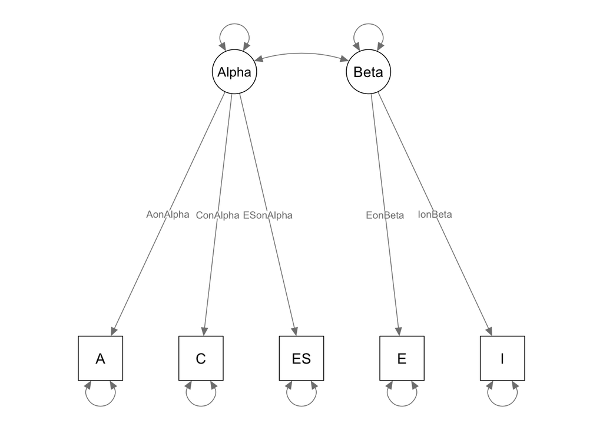

```r
# Plot the path diagram with labeled edges
plot(random2,
     whatLabels = "path",
     edge.label.cex = 0.8)  # Adjust label size for better readability
```

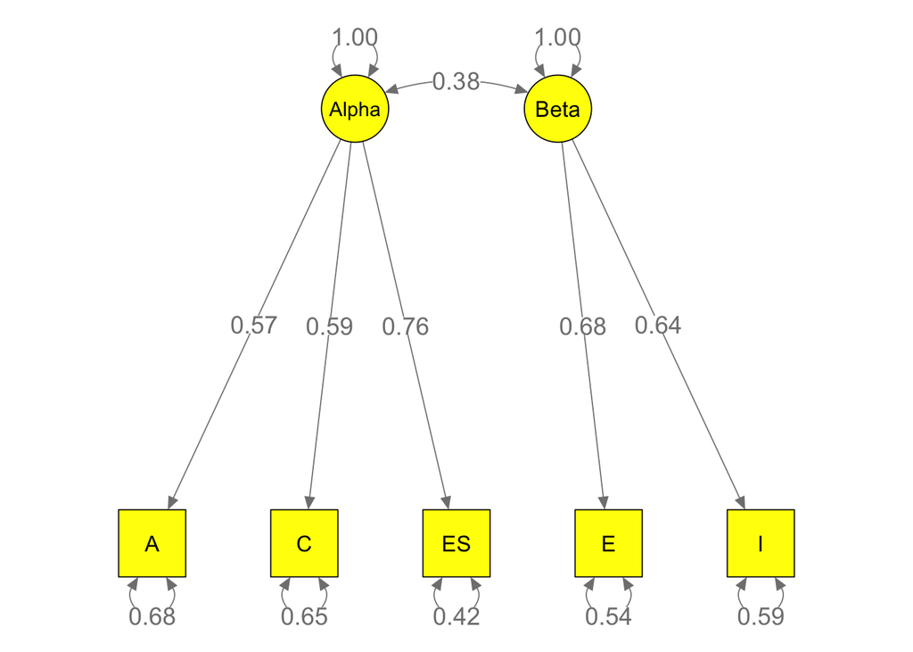

```r
# Plot the parameter estimates with a specified color
plot(random2,
     color = "yellow")  # Set node color to yellow
```